# Homework 2

Kai Oda

1/25/2020

### Objectives

In this homework assignment, you will:

1. Apply your plotting skills to visualize data before analysis
2. Decide on an appropriate t-test and formulate statistical hypotheses
3. Conduct t-tests and generate confidence intervals
4. Interpret results
5. Investigate the robustness of the two sample test using Type I errors
6. Understand statistical power and Type II errors

### Q1: Flycatcher patches (22 pts)

#### (a. 1pt) Load the FlycatcherPatch dataset from the abd package and read the corresponding information in the help tab. Show the first six lines of the data.

[output not shown]

```
##   patch98 patch99
## 1    10.5     9.3
## 2    10.6     9.2
## 3     8.7     9.3
## 4     8.6     9.1
## 5     9.0     9.0
## 6     9.3     8.7
```

#### (b. 5pts) Create an appropriate plot to visualize the data. Write one or two sentences describing the data.

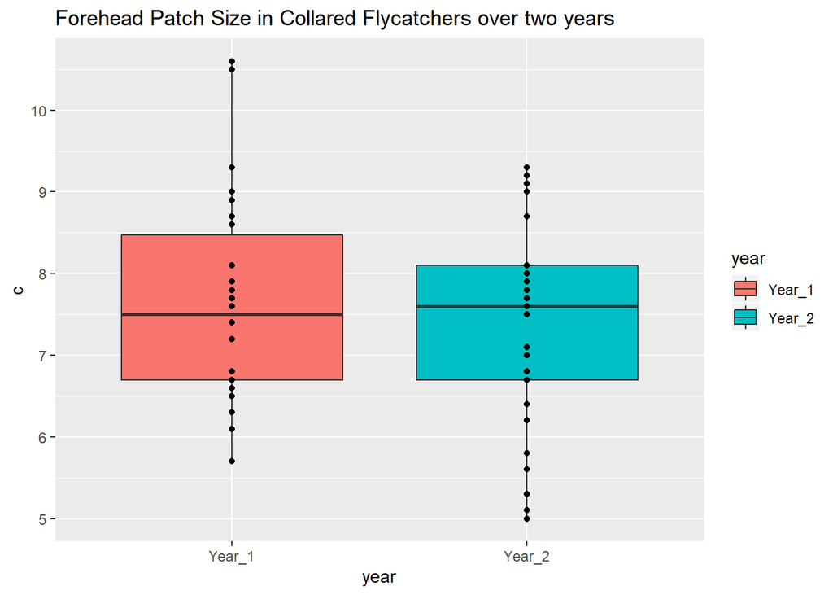

```
## $x
## [1] "Year"
##
## $y
## [1] "Forehead patch size (unknown units)"
##
## attr(,"class")
## [1] "labels"
```

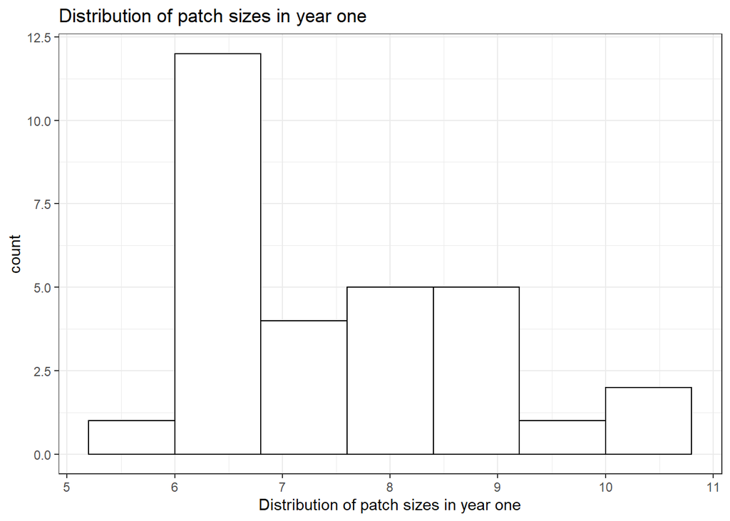

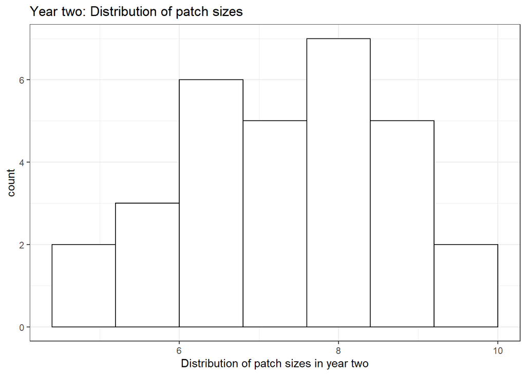

In year two flycatcher patch size had a slightly higher median and was less variable compared to year one. This trend is shown in the set of histograms — year one patch size is right skewed while year two patch sizes appear more normally distributed. However, it is difficult to tell if there was a significant difference in patch size between the two years.

#### (c. 2pts) Write the null and alternative hypotheses for a paired t-test for this dataset.

**Null Hypothesis:** There is no difference in the mean of the differences (the mean of the differences is equal to zero) between year one and year two for forehead patch size.  
**Alternative hypothesis:** There is a difference in the mean of differences between year one and year two for forehead patch size. The mean of the differences is not zero.

#### (d. 3pts) Conduct a paired t-test by first calculating the values needed to calculate the t value:

(Hint: You will need to create a column of differences)

The mean difference is **0.2266667**, the standard deviation is **0.8291805**, and the standard error of the mean is **0.1513869**.

#### (e. 2pts) Now calculate the t value and find the critical t value using the appropriate R function ($\frac{\alpha}{2}$=0.025)

The t-value is `1.497` and t* is `2.045`.

#### (f. 1pt) What is your *two-sided* p-value?

My p-value is `0.145`.

#### (g. 2pts) Conduct a paired test using the t.test function and compare to your calculations. Interpret the results of these tests by explaining whether or not you reject the null hypothesis.

We cannot reject the null hypothesis the mean of differences between forehead patch size over two years is equal to zero. Since our calculated tval is less extreme than the critical t_star value we cannot reject the null hypothesis.

#### (h. 2pts) What would be the null and alternative hypotheses for a two sample test?

Null hypothesis - There is no difference between the mean of forehead patches collected during the first year and the mean of the second year.  
Alternative hypothesis - There is a significant difference in the mean of forehead patches collected between the two years.

#### (i. 2pts) Conduct a two-sample t-test using the t.test function and assuming equal variances. State your conclusions in terms of the null hypothesis.

Because the p value is greater than 0.05 we cannot reject the null hypothesis that the difference of the means for year one and two is equal to zero.

#### (j. 2pts) Explain the difference between a paired and two-sample test and which one is more appropriate for this dataset.

A paired t-test is used to compare the mean of the difference between non-independent subjects. In short, the paired t-test is a one sample t test on the difference between two samples. A two-sample test is used to used to compare the difference of the means of two independent samples.

A paired t-test is most appropriate for this dataset, because the two samples have the same conditions for everything except the variable we are testing for — the difference in forehead patch across two separate years. Otherwise, the environment, sex and population size are all the same between the two populations.

### Q2: Dominant hand vs/ weak hand dexterity (18 pts)

#### Use the file with your dexterity results for this problem.

https://docs.google.com/spreadsheets/d/1SrhY3qzY3fk_quT9HiRbT7kPuaWHUQEXMCycmmeihwg/edit#gid=0

#### Use a paired t-test to answer the following question: *Does writing the phrase take a different amount of time with your weak v. dominant hand?*

#### (a. 2pts) Clearly state your null and alternative hypotheses of your paired t-test.

Null hypothesis - The mean of differences in writing time between one’s weak vs. dominant hand is equal to zero.  
Alternative hypothesis - The mean of differences in writing time between one’s weak vs. dominant hand is **not** equal to zero.

#### (b. 3pts) Visualize your data in a meaningful way and describe what you are showing.

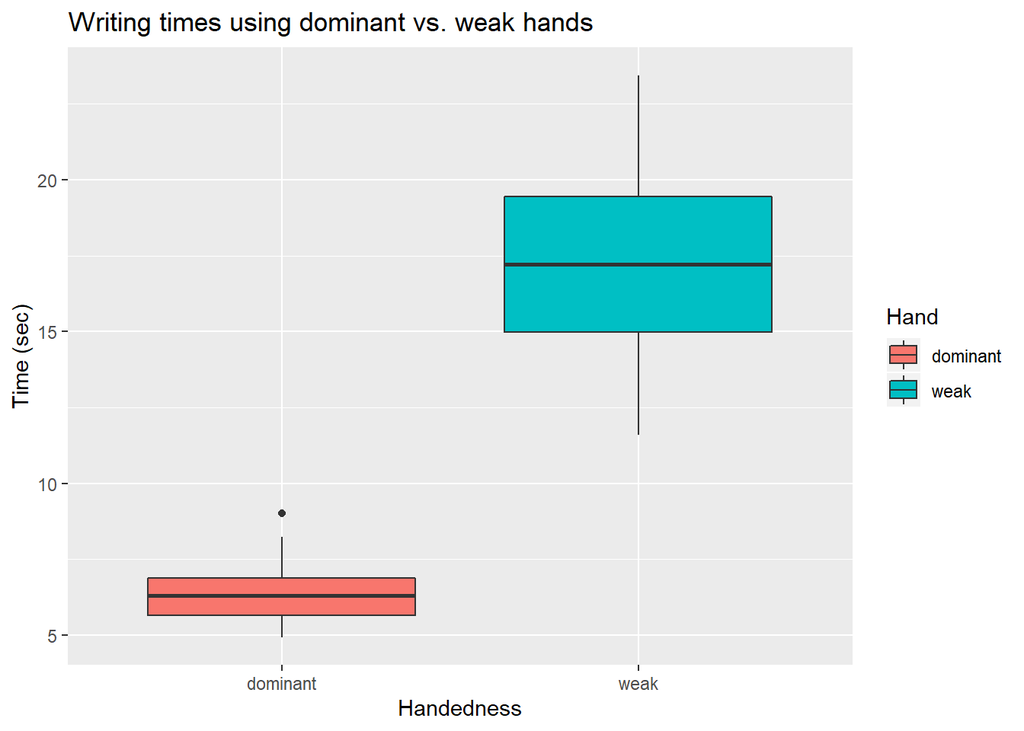

This graph shows that writing time is shorter when one uses their dominant hand compared to their weak hand. Additionally, the range of times that it takes to write with one’s weak hand is greater when compared to the range of dominant hands.

#### (c. 3pts) Determine if the data are normally distributed and, if not, whether you think the Central Limit Theorem will allow you to use a statistical test that assumes normality. Include both a Q-Qplot and a Shapiro Wilk statistic.

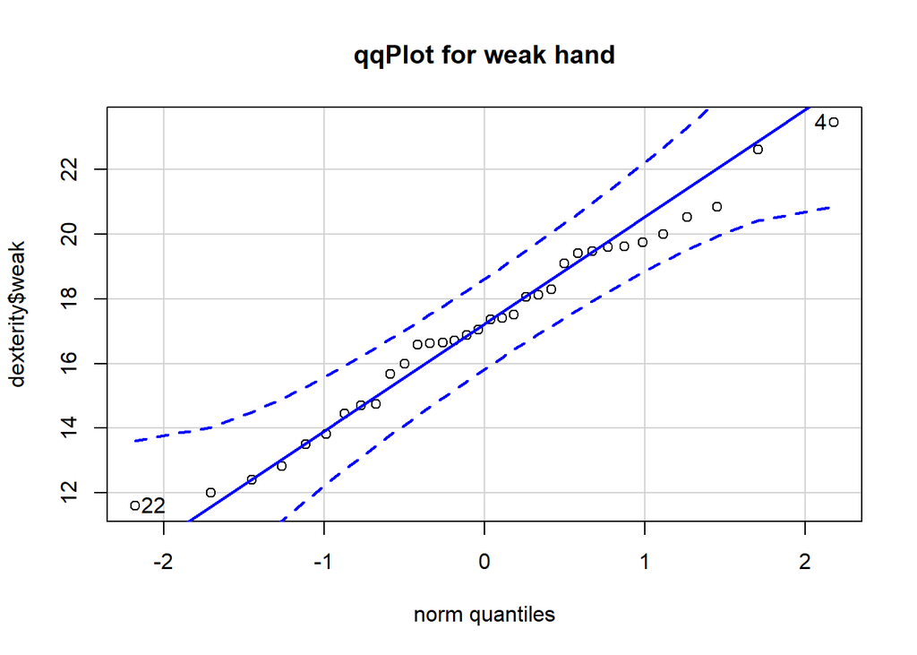

```
## [1]  4 22
```

```
##
##  Shapiro-Wilk normality test
##
## data:  dexterity$weak
## W = 0.98038, p-value = 0.7846
```

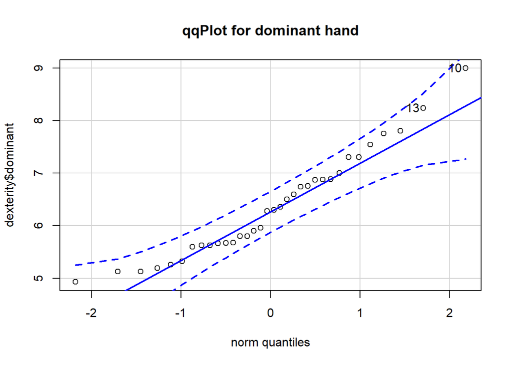

```
## [1] 10 13
```

```
##
##  Shapiro-Wilk normality test
##
## data:  dexterity$dominant
## W = 0.94839, p-value = 0.1099
```

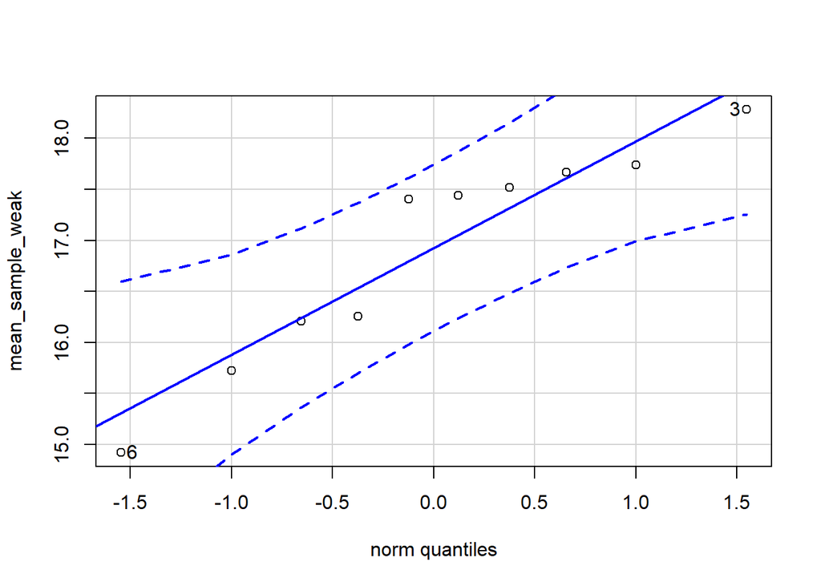

```
## [1] 6 3
```

```
##
##  Shapiro-Wilk normality test
##
## data:  mean_sample_weak
## W = 0.90701, p-value = 0.2611
```

The data **is** normally distributed. The qqPlot of the “weak” column shows that data points are inside of the confidence interval. Additionally, the shapiro-wilk test returns a p-value greater than 0.05, which means that we **cannot** reject the null hypothesis of the data being normally distributed. The shapiro test for the “dominant” column returns the same trend — we cannot reject the null hypothesis that the data is normally distributed for writing times with the dominant hand.  
However, if the data was not normally distributed by taking an increasing number of samples/sample sizes from the non-normal dataset and graphing the distribution of means we can approach a normal distribution.

#### Regardless of whether you think the assumptions of the t-test hold, report the 95% confidence interval for the mean difference using the following steps:

#### (d. 3pts) First, calculate this manually by finding the mean, sd, se, and t value

My mean is `10.79` and SE = `0.461`. The critical t value is `2.0345`.

#### (e. 2pts) Now calculate and report the interval:

The 95% confidence interval for the mean difference in dexterity [LEFT-RIGHT] is [9.8534244,11.7295168].

#### (f. 2pts) Find the 95% CI using the t.test function in R. Does it match your results?

The test **does** match my results, returning a confidence interval of [9.85, 11.73]

#### (g. 3pts) Use the 95% CI to reject or fail to reject your null hypothesis. State your conclusions about the dominant v. weak hand dexterity.

Our null hypothesis is that the mean of differences in writing time between the left and right hand is equal to zero. The confidence interval of [9.85, 11.73] does not include the null hypothesis. Therefore, we **can** reject the null hypothesis that the mean of differences between left and right hand writing times is equal to zero.  
Conclusion: The mean of differences in writing time between left and right hands is **not** equal to zero.

### Q3: Natural selection in birds (30 pts)

In 1898, Hermon Bumpus collected data on one of the first examples of natural selection directly observed in nature. Immediately following a bad winter storm, 136 English house sparrows were collected and brought indoors. Of these, 72 subsequently recovered, but 64 died :(. Bumpus made several measurements on all of the birds, and he was able to demonstrate strong natural selection on some of the traits as a result of this storm.

Bumpus published all of his data, and you can find them in the file *bumpus.csv*. In this problem, you will test whether the birds that survived or died (survival) differed in *total length* (total_length_mm).

#### (a. 2pts) Clearly state your null and alternative hypotheses of your two-sample t-test.

**Null hypothesis:** There is no difference in the mean total length between birds that survived the winter storm and those that died.  
**Alternative hypothesis:** There *is* a difference in the mean total length between birds that survived the winter storm and those that perished.

#### (b. 5pts) Visualize your data in some meaningful way, and explain what information you get from the visualization.

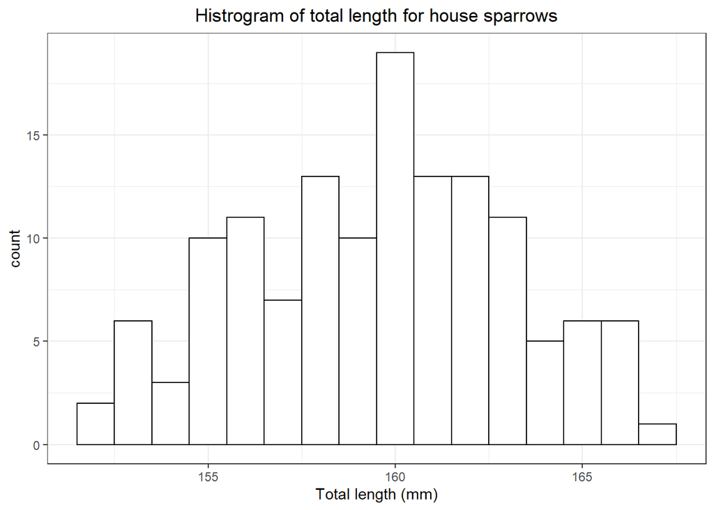

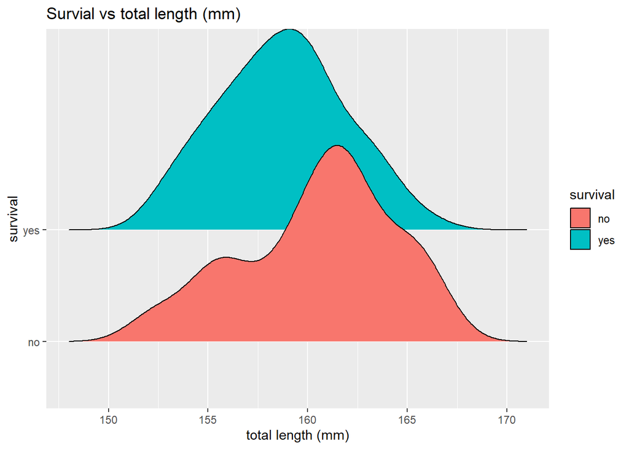

From the histogram the total length of the birds appears to be relatively normally distributed (no strong right/left skew in the data). However, a qqPlot/shapiro test would be needed to confirm normality. However, assuming the data is normally distributed we can move forward with a two-sample t test.

#### (c. 2pts) What is the appropriate test you should use to compare mean body length between dying and surviving birds? Write the null and alternative hypotheses.

The appropriate test is a **two-sample t test**  
**Null hypothesis:** There is no difference in the mean total length for birds that survived and those that perished.  
**Alternative hypothesis:** There is a difference in the mean total length for birds that survived and those that died.

#### (d. 3pts) Are the data normal? Include the Shapiro-Wilk p-value and the Q-Qplot and explain how this influences your choice of statistical test.

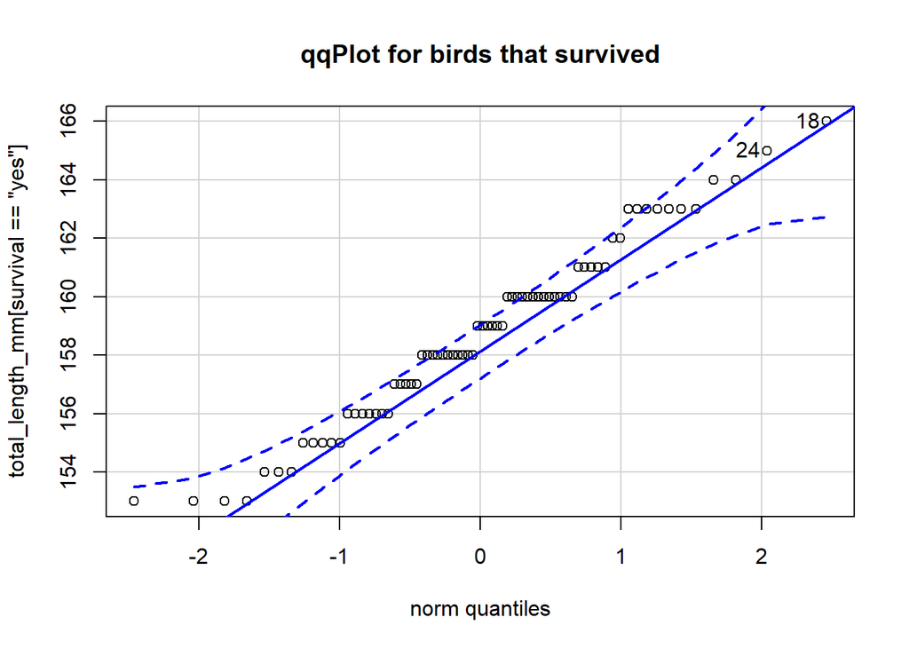

```
## [1] 18 24
```

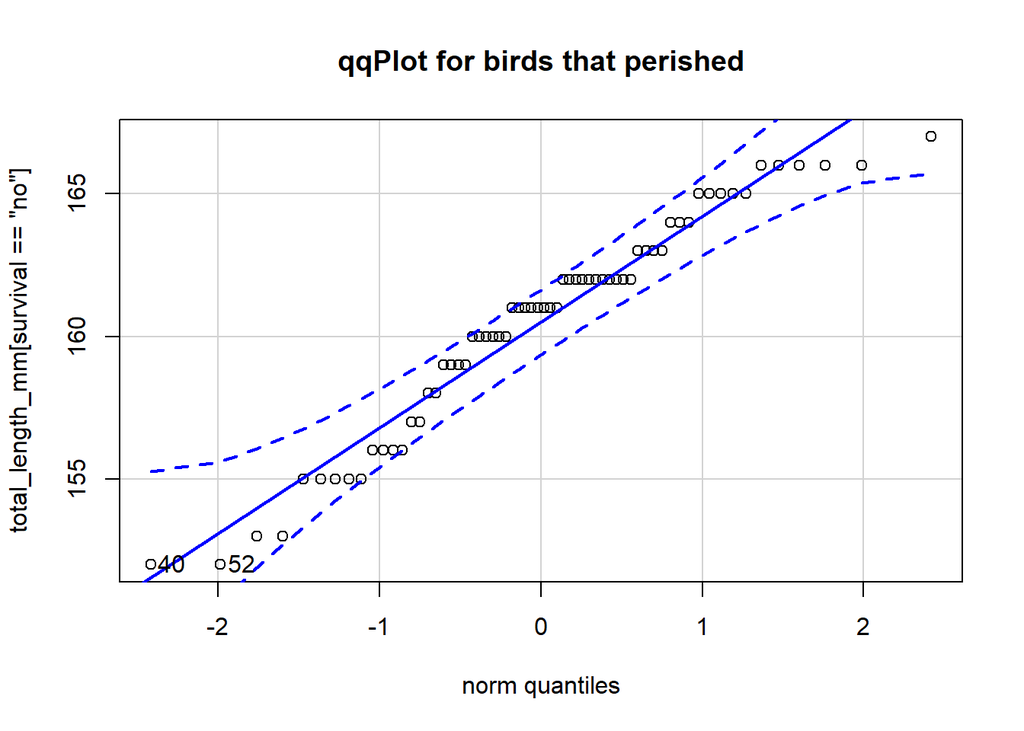

```
## [1] 40 52
```

```
##
##  Shapiro-Wilk normality test
##
## data:  total_length_mm[survival == "yes"]
## W = 0.97577, p-value = 0.1787
```

```
##
##  Shapiro-Wilk normality test
##
## data:  total_length_mm[survival == "no"]
## W = 0.9538, p-value = 0.01767
```

The shapiro test shows that the data for the birds that survived is normal (p value > 0.05, cannot reject the null hypothesis that the data is normal).  
However, the data is not normal for the birds that died as the pvalue is < 0.05. Thus, we are forced to reject the null hypothesis that the data is normal.

#### (e. 3pts) Compare the F (var.test) and levene tests (in the car package) for testing unequal variances. Which one should you use for these data?

```
##
##  F test to compare two variances
##
## data:  bumpus_survive$total_length_mm and bumpus_DIE$total_length_mm
## F = 0.66056, num df = 71, denom df = 63, p-value = 0.09035
## alternative hypothesis: true ratio of variances is not equal to 1
## 95 percent confidence interval:
##  0.4057241 1.0678885
## sample estimates:
## ratio of variances
##          0.6605612
```

```
## Levene's Test for Homogeneity of Variance (center = median)
##        Df F value Pr(>F)
## group   1  1.6668 0.1989
##       134
```

The null hypothesis for the F test is that the ratio of variances is equal to one. This occurs when the variances of the two samples are equal.  
The null hypothesis for the Levene test is that the variances are equal.  
In this case, since the P value the F test and Levene test was greater than 0.05, we cannot reject the null hypothesis (variance between total length of alive/dead birds is equal). However, since the F test is sensitive to data that is not normally distributed (and birds that perished are not normally distributed), I decided to use the Levene’s test.  
But to reiterate, we **cannot** reject the null hypothesis that the variances are equal with the Levene test. Therefore, we can use a t test instead of a Welch’s t-test.

#### (f. 2pts) Conduct the appropriate t-test and state your conclusions in terms of the null hypothesis.

```
##
##  Two Sample t-test
##
## data:  bumpus_survive$total_length_mm and bumpus_DIE$total_length_mm
## t = -2.9873, df = 134, p-value = 0.003348
## alternative hypothesis: true difference in means is not equal to 0
## 95 percent confidence interval:
##  -2.9519334 -0.6001499
## sample estimates:
## mean of x mean of y
##  158.7083  160.4844
```

Since the p value is less than 0.05 we reject the null hypothesis that there is no difference in mean total length between birds that survived and those that died.  
Therefore, we accept the alternative hypothesis that **there is a difference in mean total length** between birds that survived and those that perished.

#### (e. 10pts) Conduct your own statistical test on any other measurement in the dataset. Visualize the data, state your hypotheses, check assumptions, conduct your test, and report results.

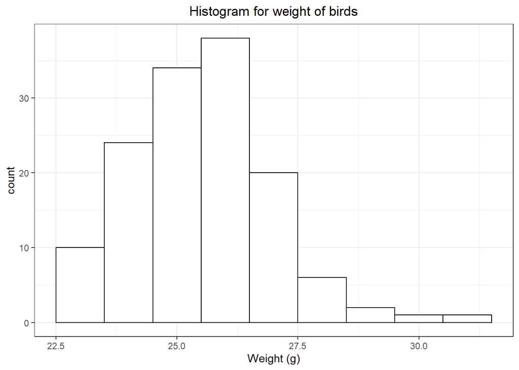

**Null hypothesis:** The mean weight of birds that survived and those that died is the same.  
**Alternative hypothesis:** The mean weight of birds that survived and those that died is **different.**  
#### **Tests for normality**

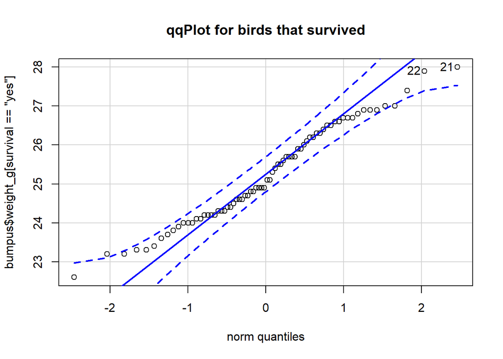

```
## [1] 21 22
```

```
##
##  Shapiro-Wilk normality test
##
## data:  weight_g[survival == "yes"]
## W = 0.97394, p-value = 0.1402
```

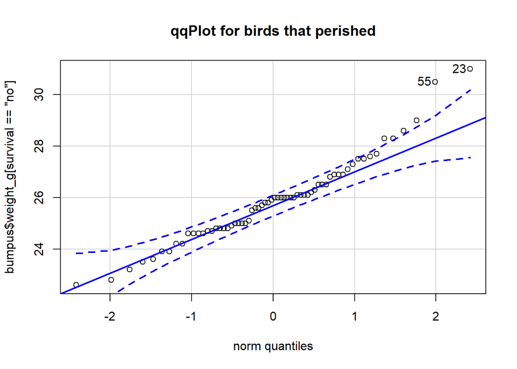

```
## [1] 23 55
```

```
##
##  Shapiro-Wilk normality test
##
## data:  weight_g[survival == "no"]
## W = 0.96024, p-value = 0.03756
```

```
## Levene's Test for Homogeneity of Variance (center = median)
##        Df F value Pr(>F)
## group   1  0.8256 0.3652
##       134
```

**Normally distributed:** The weight of birds that survived is normally distributed. However, the weight of birds that did not survive is not normally distributed. However, we are still going to forge ahead keeping in mind the power of our test is reduced because one of the assumptions is not met.  
**Variance:** Because the p value is greater than 0.05 we cannot reject the null hypothesis. Therefore, the variances are equal and we can move forward with the t test.  
## T-test for weight of alive/perished birds

```
##
##  Two Sample t-test
##
## data:  bumpus_survive$weight_g and bumpus_DIE$weight_g
## t = -2.5545, df = 134, p-value = 0.01175
## alternative hypothesis: true difference in means is not equal to 0
## 95 percent confidence interval:
##  -1.1258476 -0.1432496
## sample estimates:
## mean of x mean of y
##  25.22639  25.86094
```

Since the p value is less than 0.05 we reject our null hypothesis that the mean weights of birds that died and those that survived are equal.  
Therefore, we accept the alternative hypothesis that there is a difference between the weight of birds that survived and those that died.

### Q4: Robustness of the t-test (30pts)

The t-test is fairly robust to its assumptions. This means that even when the assumptions are not correct, the t-test often performs quite well. Remember that the two-sample t-test has the following assumptions:

** The variables have a normal distribution in the populations

** The variance of those distributions is the same in the two populations

** The two samples are random samples.

To get started on this exercise, open the script *robustness.R*. It should pop up in another tab in your R Studio console. This script allows you to test how robust the results of t-test are to data that violate the assumptions. First, specify what the true distributions look like. You can do this by altering the code in the top few lines of the script.

To start, run all the code in the script using *Run > Run all*. Two things should happen:

1. you should see a plot pop up that shows you the shape of your two distributions, and
2. R will output either your type I error if your true means are the same or your type II error if your true means are different. You should see something like:

[1] “Your true TYPE I ERROR RATE is: 0.0498”

This value should be close to 0.05 when the assumptions are met, which is our pre-set type I error $(\alpha = 0.05)$.

Here is what just happened: R just artificially created 5,000 samples of 5 individuals each from both populations, and ran 5000 t-tests comparing the means. It tallied the number of significant and non-significant t-tests. In this case, both distributions are normal and the variances are equal, just as assumed by the t-test. We expect the t-test to work quite well in this case.

Take a moment to think about what “working well” means. If the null hypothesis is true, then the Type 1 error rate given by the simulation should be close to our stated Type I error rate, $\alpha$. *Remember that Type I error is falsely rejecting a true null hypothesis*. An inflated Type I error rate means that we falsely reject the null hypothesis more than our pre-specified rate $\alpha$.

Answer the following questions as you explore the effect of distribution shape and sample size on your Type I error. You do NOT need to include any of the code from the script.

#### (a. 5pts) *Unequal standard deviation, equal sample size*.

Make the standard deviations of the two populations unequal (all other parameters equal). What happens to the Type I error? Explore multiple combinations of standard deviations. What do you notice?

The shape of the two populations appears to vary dramatically, but both still appear more or less normal. The Type I error increased slightly (0.05 to 0.08), but this is not an alarming increase considering the samples are generated randomly.  
Changing combinations of standard deviations does not increase the p value, the t test still appears to work well.

#### (b. 5pts) *Unequal standard deviation, unequal sample size*.

Keep the standard devations unequal and increase the sample size of one of the populations. Now exchange sample size 1 and sample size 2. What do you notice?

As the sample size increases, the Type I error rate remains zero (despite a very large difference between the size of the samples).  
Exchanging the sample size of population 1 and 2 increased theType I error rate to 0.825.

#### (c. 5pts) *Skew, equal sample size*.

Set the standard deviations of both populations to 1, the means of both populations to 4, and the sample size of both populations to 5. Change the skew of the second population to true (SKEWED2 = TRUE).

The shape of population two is right skewed while population one remains normally distributed.

##### What is your type I error rate?

0.125

##### What is the effect of changing the mean for both populations (still keeping them equal)?

Increasing the means results in a flatter looking curve, though the population two still appears to be right skewed. The Type I error rate increased to 0.155.

##### Play around with the sample sizes. Approximately how many samples are needed to attain a Type I error rate close to 0.05? (assume equal sample sizes)

A sample size of 120 returned a Type I error rate of 0.057.

#### (d. 5pts) Set the sample size = 25 for both populations, keeping means equal. Try two or three combinations that you think will give you an inflated Type I Error Rate. Do you think that the t-test is robust to violations of its assumptions if your sample size is large enough? Explain why or why not based on the value of your type I error rates.

I tried changing both populations to be skewed –> Error = 0.0466 Tried making the SD of the normal population extremely large –> 0.0558 Tried making the SD of the skewed population extremely large –> 0.081

Based on the above results, I could not find a way to generate a large type I error rate if the means and sample sizes are the same. Therefore, if the sample size is large enough it appears that the t test is robust to violations (assuming the sample sizes are the same).

#### (e. 5pts) Now set your sample means to be different from each other. Set sample 1 mean = 20 and sample 2 mean = 15. Assuming that SD for both samples is 3, how many samples are needed to get a type II error = 0.2?

7 samples were required to return a type II error of 0.177.

#### (f. 2pts) What does this tell you about the power of your test?

Few samples are required in order to maintain the same level of power (be able to reject a false null hypothesis) if the means are different. Therefore, our test has high power since 1-B returns a relatively large value.

#### (g. 3pts) Finally, keep the same parameters as in part E, but set the population with mean=15 to be skewed. What happened to your type II error? About how many samples are needed for each group (assume equal sample sizes) to reduce it to 0.2?

The type II error dramatically increased when population 2 was set to skewed (0.7). 85 samples were required to return a type II error of 0.19